# Trump Vote Request

```r
library(knitr)
library(kableExtra)
library(data.table)
library(readr)
library(stringi)
library(RtextminerPkg)
library(RplotterPkg)
library(RtsaPkg)
library(tm)
library(sentimentr)
library(here)

current_dir <- here()
```

Author: Rick Dean

Article date: 2021-09-10

Abstract

The following R script is an analysis of the Trump phone call to Georgia’s Secretary of State Brad Raffensperger on the presidential election results in that state (January 4, 2021).

## Study Outline

### Read the phone transcript data

```r
data_file_path <- file.path(current_dir, "trump_vote_request.txt")
linesInFile <- base::readLines(data_file_path)
```

### Show file statistics

```r
fileSize <- format(object.size(linesInFile), units = "Kb")
fileNoLines <- length(linesInFile)
fileWords <- sum(stringi::stri_count_words(linesInFile))

cat(" File size: ", fileSize, " Lines in file: ", fileNoLines, " Words in file: ", fileWords)
```

```
##  File size:  63.5 Kb  Lines in file:  293  Words in file:  10026
```

### Get the sentence collection

```r
sentences_v <- unlist(sentimentr::get_sentences(linesInFile))
sentences_dt <-  data.table(
  sentence_no = 1:length(sentences_v),
  sentence_text = sentences_v
)
```

### Remove blanks from the sentence collection

```r
sentences_dt <- sentences_dt[nchar(sentence_text) > 1]
```

### Tokenize the lines to words

Note: We are defining stopwords from the [tm package](https://cran.r-project.org/web/packages/tm/index.html). The word “trump” occurs in the text 64 times and has several meanings. Because “trump” is a personal name we will include it in the vector of stopwords.

```r
words_dt <- RtextminerPkg::tokenize_text(
  x = sentences_dt,
  input_col = "sentence_text",
  stopwords = append(tm::stopwords("en"), "trump"),
  strip_numeric = T,
  strip_punct = T,
  strip_non_alphanum = T
)
head(words_dt$tokens_dt,n = 10)
```

```
##     sentence_no       word
##  1:           1         ok
##  2:           1      thank
##  3:           1       much
##  4:           2      hello
##  5:           2       brad
##  6:           2       ryan
##  7:           2  everybody
##  8:           3 appreciate
##  9:           3       time
## 10:           3       call
```

### Plot the 20 most common words

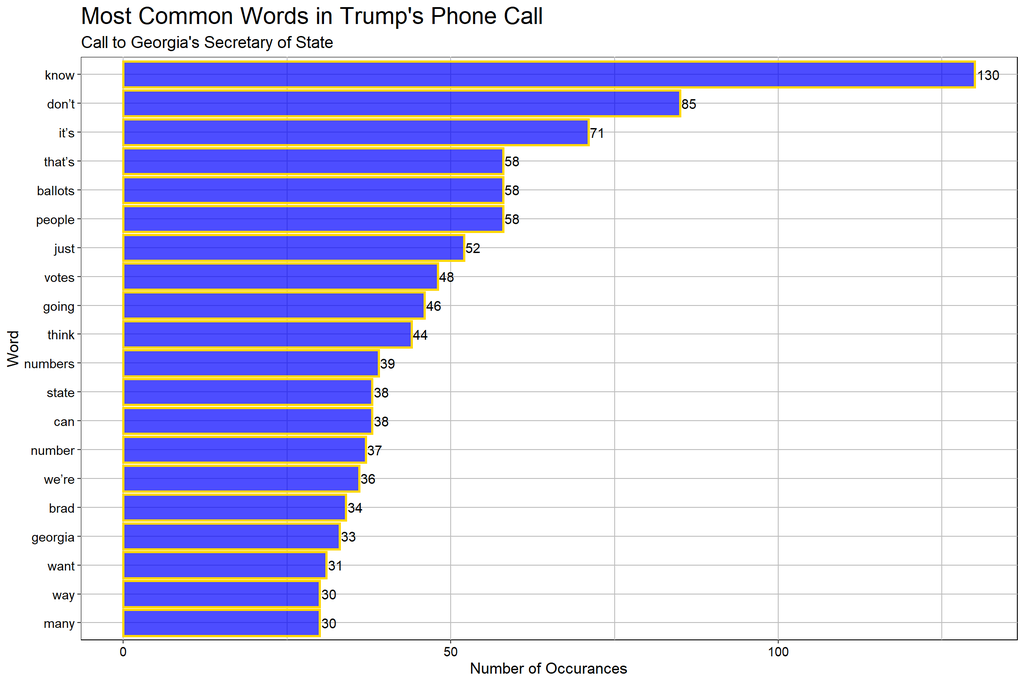

```r
RplotterPkg::create_bar_plot(
  df = words_dt$tokens_count[1:20],
  aes_x = "word",
  aes_y = "N",
  title = "Most Common Words in Trump's Phone Call",
  subtitle = "Call to Georgia's Secretary of State",
  x_title = "Word",
  y_title = "Number of Occurances",
  rot_y_tic_label = T,
  bar_fill = "blue",
  bar_color = "gold",
  bar_alpha = 0.7,
  do_coord_flip = T,
  order_bars = "asc",
  bar_labels = T
)
```

### Relationship of the word “know”

The word “know” has the highest frequency in the conversation. What is the relationship of this word with other words. To accomplish this we will perform an N-gram analysis.

1. Perform 2-gram tokenization: Note: By default `n-gram` = 2 for `RtextminerPkg::tokenize_text()`

```r
bigrams_dt <- RtextminerPkg::tokenize_text(
  x = sentences_dt,
  input_col = "sentence_text",
  type = "ngram"
)
```

2. Paste the 2 words together in a separate column to form the `bigram` variable in the data.table`bigrams_dt$tokens_count`:

```r
bigrams_dt$tokens_count[, bigram := paste(token_1, token_2)]
```

3. Plot the 22 top 2-gram’s:

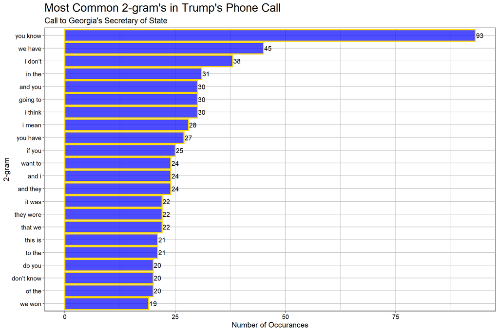

```r
RplotterPkg::create_bar_plot(
  df = bigrams_dt$tokens_count[1:22],
  aes_x = "bigram",
  aes_y = "N",
  title = "Most Common 2-gram's in Trump's Phone Call",
  subtitle = "Call to Georgia's Secretary of State",
  x_title = "2-gram",
  y_title = "Number of Occurances",
  rot_y_tic_label = T,
  bar_fill = "blue",
  bar_color = "gold",
  bar_alpha = 0.7,
  do_coord_flip = T,
  order_bars = "asc",
  bar_labels = T
)
```

The phrase “you know” appears to be the most frequent 2-gram. The phrase “we won” has some interesting context.

```r
we_won_dt <- sentences_dt[data.table::like(sentences_dt$sentence_text, "we won",ignore.case = T)]
```

```r
we_won_table <- RplotterPkg::create_table(
  x = we_won_dt,
  caption = "'we won' phrases",
  fixed_thead = T,
  scroll_height = "400px"
)
we_won_table
```

‘we won’ phrases

| sentence_no | sentence_text |
| --- | --- |
| 3 | We appreciate the time and the call, um, so we’ve spent a lot of time on this, and if we could just go over some of the numbers, I think it’s pretty clear that we won. |
| 4 | We won very substantially, Georgia. |
| 53 | They, they beat me in the — as you know, every single state, we won every state. |
| 54 | We won every statehouse in the country. |
| 56 | And we won the House, but we won every single statehouse, and we won Congress, which was supposed to lose 15 seats, and they gained I think 16 or 17 or something. |
| 103 | And we won the state, and we won it very substantially and easily. |
| 135 | You know, we won the state. |
| 148 | I think I probably did win it by half a mill — I mean, you know, one of the things that happened, Brad, is we have other people coming in now from Alabama and from South Carolina and from other states… |
| 375 | We won by hundreds of thousands of votes. |
| 544 | I just want to find 11,780 votes, which is one more than we have because we won the state. |
| 702 | We won the election, and it’s not fair to take it away from us like this. |
| 761 | I’m not looking to shake up the whole world, we won Georgia easily. |
| 762 | We won it by hundreds of thousands of votes, but if you go by basic, simple numbers, we won it easily, easily. |
| 810 | Because I know Brad that if, if you think we’re right, I think you’re going to say, and I’m not looking to blame anybody, I’m not blaming, I’m just saying that, you know, you don’t want under new coun… |
| 811 | You know, it’s very simple, we won the election. |

### Measure the sentiment of each sentence

The R package being used here for sentiment measurement is [sentimentr::sentiment()](https://github.com/trinker/sentimentr) where the author states “is designed to quickly calculate text polarity sentiment at the sentence level and optionally aggregate by rows or grouping variable(s).” He goes on to say that “sentimentr attempts to take into account valence shifters (i.e., negators, amplifiers (intensifiers), de-amplifiers (downtoners), and adversative conjunctions) while maintaining speed.”

```r
sentence_sentiment_dt <- sentimentr::sentiment(sentences_dt$sentence_text)
sentence_sentiment_dt[,sentence_id := sentences_dt$sentence_no]
head(sentence_sentiment_dt, n = 10)
```

```
##     element_id sentence_id word_count   sentiment
##  1:          1           1          6  0.32659863
##  2:          2           2          6  0.00000000
##  3:          3           3         38  0.32444284
##  4:          4           4          5  0.88548292
##  5:          5           5          8  0.00000000
##  6:          6           6         28 -0.04724556
##  7:          7           7         17 -0.12126781
##  8:          8           8         14  0.00000000
##  9:          9           9         50 -0.16970563
## 10:         10          10          4  0.00000000
```

### Plot the sentiment measures

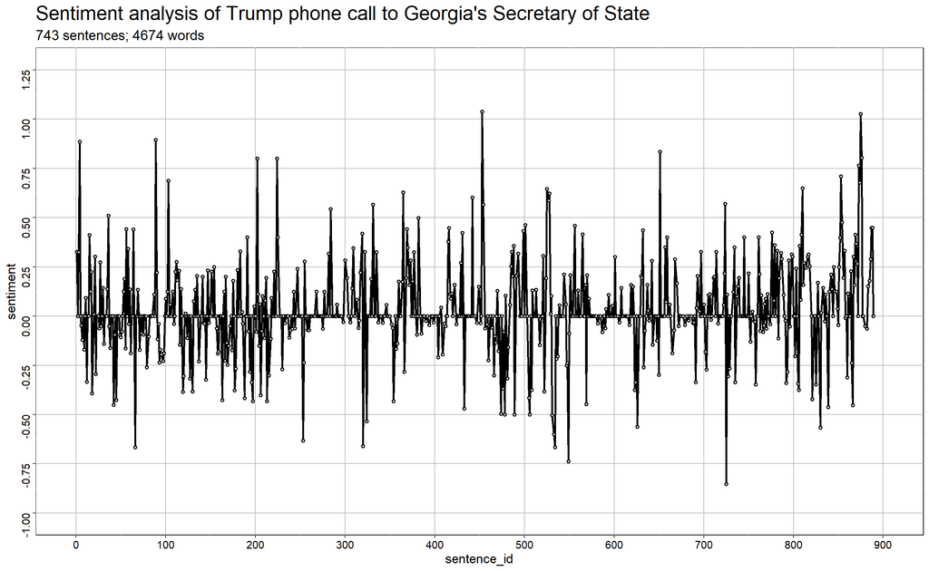

```r
RplotterPkg::create_scatter_plot(
  df = sentence_sentiment_dt,
  aes_x = "sentence_id",
  aes_y = "sentiment",
  connect = T,
  x_limits = c(0,900),
  x_major_breaks = seq(0,900,100),
  y_limits = c(-1,1.25),
  y_major_breaks = seq(-1,1.25,0.25),
  show_minor_grids = F,
  title = "Sentiment analysis of Trump phone call to Georgia's Secretary of State",
  subtitle = "743 sentences; 4674 words"
)
```

```r
postive_sentences_dt <- data.table(
  sentence_no = c(453,875,549,725),
  sentence_text = c("Go ahead, please.",
                    "And the truth, the real truth is I won by 400,000 votes, at least.",
                    "It was much more criminal than that.",
                    "They’re really wrong, and they’re really wrong, Brad."),
  sentiment = c(1.039, 1.026,-0.737,-0.854)
)
postive_table <- RplotterPkg::create_table(
  x = postive_sentences_dt,
  caption = "Significant Sentences"
)
postive_table
```

Significant Sentences

| sentence_no | sentence_text | sentiment |
| --- | --- | --- |
| 453 | Go ahead, please. | 1.039 |
| 875 | And the truth, the real truth is I won by 400,000 votes, at least. | 1.026 |
| 549 | It was much more criminal than that. | -0.737 |
| 725 | They’re really wrong, and they’re really wrong, Brad. | -0.854 |

```
## $ma_df
##      DateTime     Value
##   1:        1 0.3265986
##   2:        2 0.1632993
##   3:        3 0.2170138
##   4:        4 0.3841311
##   5:        5 0.3073049
##  ---
## 739:      885 0.3488058
## 740:      886 0.3012746
## 741:      887 0.2781559
## 742:      888 0.2205364
## 743:      889 0.1400379
##
## $plots
```

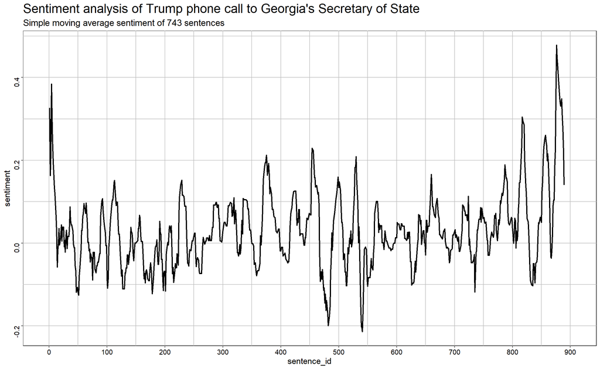

```r
RtsaPkg::graph_ma(
  df = sentence_sentiment_dt,
  time_col = "sentence_id",
  value_col = "sentiment",
  window_n = 10,
  #ma_type = "wma",
  show_observe = F,
  title = "Sentiment analysis of Trump phone call to Georgia's Secretary of State",
  subtitle = "Simple moving average sentiment of 743 sentences",
  x_limits = c(0,900),
  x_major_breaks = seq(0,900,100),
  show_pts = F,
  display_plot = F
)
```

There appears to be some negative sentiment spiking near the middle of the conversation.